# Desafio02

Author

Nicole de Barros Silva

## **Laboratório 2: Processamento de Bases de Dados em Lote**

**Benilton Carvalho & Guilherme Ludwig**

## **Introdução**

A coleta de dados em épocas mais recentes teve seu custo reduzido e volume ampliado significativamente. Redes sociais combinadas com dispositivos móveis rastreiam bilhões de pessoas no mundo, com informações das mais diversas origens: rotinas de passeio, amizades, históricos de compras, históricos de localização, fotografias geo-referenciadas, etc (FYI: com o escândalo da Cambridge Analytica, surgiram evidências de que o Facebook tenha registros de histórico de chamadas e SMS, para mensagem e ligações ocorridas fora do aplicativo Facebook, em telefones Android: https://www.theverge.com/2018/3/25/17160944/facebook-call-history-sms-data-collection-android). Empresas, por meio de programas de fidelidade, aprendem hábitos de compras, propensidade de compras de certos produtos dependendo de horários, produtos que são comprados juntos e informações financeiras referentes a pagamentos. Desta maneira, o volume das bases de dados cresce vertiginosamente, de modo que é necessária a mudança de paradigma na estatística moderna: os dados não mais podem trafegar até o analista de dados; a análise deve ser transportada até os dados.

# **Objetivos**

Ao fim deste laboratório, você deve ser capaz de:

- Importar um arquivo volumoso por partes;
- Calcular estatísticas suficientes para métrica de interesse em cada uma das partes importadas;
- Manter em memória apenas o conjunto de estatísticas suficientes e utilizar a memória remanescente para execução de cálculos;
- Combinar as estatísticas suficientes de modo a compor a métrica de interesse.

# **Tarefa (retirada dos últimos slides da última aula)**

Lendo 100.000 observações por vez (se você acredita que seu computador não tem memória suficiente, utilize 10.000 observações por vez), determine o percentual de vôos por Cia. Aérea que apresentou atraso na chegada (`ARRIVAL_DELAY`) superior a 10 minutos. As companhias a serem utilizadas são: AA, DL, UA e US. A estatística de interesse deve ser calculada para cada um dos dias de 2015. Para a determinação deste percentual de atrasos, apenas verbos do pacote `dplyr` e comandos de importação do pacote `readr` podem ser utilizados. Os resultados para cada Cia. Aérea devem ser apresentados em um formato de calendário.

Observação: a atividade descrita no slide pede para ler apenas 100 registros por vez. Aqui, mudamos para 100 mil registros por vez, para que haja melhor aproveitamento do tempo em classe.

# Instruções

1. Quais são as estatísticas suficientes para a determinação do percentual de vôos atrasados na chegada (ARRIVAL_DELAY > 10)?
2. Crie uma função chamada getStats que, para um conjunto de qualquer tamanho de dados provenientes de flights.csv.zip, execute as seguintes tarefas (usando apenas verbos do dplyr:
1. Filtre o conjunto de dados de forma que contenha apenas observações das seguintes Cias. Aéreas: AA, DL, UA e US;
2. Remova observações que tenham valores faltantes em campos de interesse;
3. Agrupe o conjunto de dados resultante de acordo com: dia, mês e cia. aérea;
4. Para cada grupo em b., determine as estatísticas suficientes apontadas no item 1. e os retorne como um objeto da classe tibble;
5. A função deve receber apenas dois argumentos: input: o conjunto de dados (referente ao lote em questão); pos: argumento de posicionamento de ponteiro dentro da base de dados. Apesar de existir na função, este argumento não será empregado internamente. É importante observar que, sem a definição deste argumento, será impossível fazer a leitura por partes.
3. Utilize alguma função readr::read_***_chunked para importar o arquivo flights.csv.zip.
1. Configure o tamanho do lote (chunk) para 100 mil registros;
2. Configure a função de callback para instanciar DataFrames aplicando a função getStats criada acima;
3. Configure o argumento col_types de forma que ele leia, diretamente do arquivo, apenas as colunas de interesse (veja nota de aula para identificar como realizar esta tarefa);
4. Crie uma função chamada computeStats que:
1. Combine as estatísticas suficientes para compor a métrica final de interesse (percentual de atraso por dia/mês/cia aérea);
2. Retorne as informações em um tibble contendo apenas as seguintes colunas: Cia: sigla da companhia aérea; Data: data, no formato AAAA-MM-DD (dica: utilize o comando as.Date); Perc: percentual de atraso para aquela cia. aérea e data, apresentado como um número real no intervalo [0,1] .
5. Produza um mapa de calor em formato de calendário para cada Cia. Aérea.
1. Instale e carregue os pacotes ggcal e ggplot2.
2. Defina uma paleta de cores em modo gradiente. Utilize o comando scale_fill_gradient. A cor inicial da paleta deve ser #4575b4 e a cor final, #d73027. A paleta deve ser armazenada no objeto pal.
3. Crie uma função chamada baseCalendario que recebe 2 argumentos a seguir: stats (tibble com resultados calculados na questão 4) e cia (sigla da Cia. Aérea de interesse). A função deverá:
4. Criar um subconjunto de stats de forma a conter informações de atraso e data apenas da Cia. Aérea dada por cia.Para o subconjunto acima, montar a base do calendário, utilizando ggcal(x, y). Nesta notação, x representa as datas de interesse e y, os percentuais de atraso para as datas descritas em x. Retornar para o usuário a base do calendário criada acima.
5. Executar a função baseCalendario para cada uma das Cias. Aéreas e armazenar os resultados, respectivamente, nas variáveis: cAA, cDL, cUA e cUS.
6. Para cada uma das Cias. Aéreas, apresente o mapa de calor respectivo utilizando a combinação de camadas do ggplot2. Lembre-se de adicionar um título utilizando o comando ggtitle. Por exemplo, cXX + pal + ggtitle(“Titulo”).

```r
library(reticulate) # Carrega o pacote reticulate, que faz a integração entre R e Python
virtualenv_create("r-reticulate", python = "C:/Program Files/Python312/python.exe") # Cria um ambiente virtual chamado "r-reticulate"
```

```
virtualenv: r-reticulate
```

```r
# Aqui o argumento python = "C:/ProgramFiles/Python312/python.exe" define explicitamente qual executável Python será usado para criar o virtualenv
```

```r
use_virtualenv("r-reticulate", required = TRUE) # Indica ao R (via pacote reticulate) que deve usar o ambiente virtual "r-reticulate".
py_config() # Mostra as informações de configuração do Python atualmente em uso pelo reticulate
```

```
python:         \\smb/ra238935/Documentos/.virtualenvs/r-reticulate/Scripts/python.exe
libpython:      C:/Program Files/Python312/python312.dll
pythonhome:     \\smb/ra238935/Documentos/.virtualenvs/r-reticulate
version:        3.12.0 (tags/v3.12.0:0fb18b0, Oct  2 2023, 13:03:39) [MSC v.1935 64 bit (AMD64)]
Architecture:   64bit
numpy:          \\smb/ra238935/Documentos/.virtualenvs/r-reticulate/Lib/site-packages/numpy
numpy_version:  2.3.2

NOTE: Python version was forced by use_python() function
```

#Questao1 As estatísticas suficientes para resolução desse problema são: a) número total de voos(para cada combinacao dia/mes/cia) b) número de voos (dentre os apontados acima) que tem a coluna arrival_delay > 10 Variáveis necessárias: AIRLINE, ARRIVAL_DELAY, DAY, MONTH

```python
#Questao2
# Função para processar cada chunk
def getStats(input, pos):
    # manter só as colunas necessárias (cria uma cópia para não modificar o DataFrame original)
    df = input[['DAY', 'MONTH', 'AIRLINE', 'ARRIVAL_DELAY']].copy()

    # filtro das cias e remover NAs nas colunas de interesse
    df = df[
        (df['AIRLINE'].isin(['AA', 'DL', 'UA', 'US'])) & # filtra apenas as 4 cias pedidas
        (df['DAY'].notna()) & # remove linhas com DAY nulo
        (df['MONTH'].notna()) & # remove linhas com MONTH nulo
        (df['ARRIVAL_DELAY'].notna()) # remove linhas com ARRIVAL_DELAY nulo
    ]

    # agrupa por AIRLINE, DAY, MONTH e calcular as estatísticas suficientes:
    result = (
        df.groupby(['AIRLINE', 'DAY', 'MONTH'], as_index=False)
        .agg(
            n=('ARRIVAL_DELAY', 'size'),  # n: número de voos
            atrasos=('ARRIVAL_DELAY', lambda x: (x > 10).sum()) # atrasos: conta quantos ARRIVAL_DELAY > 10 (atrasos superior a 10 minutos)
        )
    )

    return result# retorna um DataFrame/tibble com colunas: AIRLINE, DAY, MONTH, n, atrasos
```

```python
#Questao3
import pandas as pd # importa pandas (manipulação de tabelas)
import time # importa time para medir tempo de execução

# Leitura em chunks (100000 registros)

ini = time.time()  # marca início do processamento para medir tempo

results = []   # lista para acumular os DataFrames de cada chunk

# Lê apenas as colunas necessárias
usecols = ['DAY', 'MONTH', 'AIRLINE', 'ARRIVAL_DELAY']

# pd.read_csv com chunksize faz a leitura em blocos; aqui arquivo compactado em zip
# o loop percorre TODOS os chunks até o fim do arquivo
for i, chunk in enumerate(pd.read_csv("flights.csv.zip",
                                      compression="zip", # indica que o arquivo está compactado em zip
                                      chunksize=100000,  # tamanho do chunk (100.000 linhas por iteração)
                                      usecols=usecols)): # ler somente as colunas especificadas para economizar memória
    stats = getStats(chunk, i)   # aplica a função getStats ao chunk atual
    results.append(stats) # armazena o resultado parcial na lista

# Junta todos os resultados em um único DataFrame
in3 = pd.concat(results, ignore_index=True)

fim = time.time() # marca fim do processamento
print("Tempo de execução:", round(fim - ini, 2), "segundos") #imprime tempo total
```

```
Tempo de execução: 7.49 segundos
```

```python
#Questao4
import pandas as pd

# Define a função compute_stats que recebe um DataFrame df com colunas: AIRLINE, DAY, MONTH, n (total de voos), atrasos (número de voos atrasados > 10min)
def compute_stats(df):
    # Agrupa os dados pelas colunas AIRLINE, DAY e MONTH
    # Para cada grupo, calcula o percentual de atrasos: soma de atrasos do grupo / soma de voos (n) do grupo
    result = (
        df.groupby(['AIRLINE', 'DAY', 'MONTH'], as_index=False) # agrupa por companhia, dia e mês
          .agg(Perc=('atrasos', # cria coluna Perc
          lambda x: x.sum() / df.loc[x.index, 'n'].sum())) # calcula percentual de atrasos
    )

    # Cria uma nova coluna 'Data' combinando YEAR=2015, MONTH e DAY.
    # pd.to_datetime converte essas colunas em um formato de data válido (AAAA-MM-DD)
    result['Data'] = pd.to_datetime(
        result[['DAY', 'MONTH']].assign(Year=2015)[['Year', 'MONTH', 'DAY']]
    )

    # Seleciona apenas as colunas finais
    result = result[['AIRLINE', 'Data', 'Perc']]

    # Retorna o DataFrame processado (com as estatísticas finais de interesse)
    return result

# Aplica compute_stats ao DataFrame concatenado dos resultados parciais
in5 = compute_stats(in3)
```

```r
reticulate::py_install("matplotlib") # instala a biblioteca Python "matplotlib" (usada para criar gráficos)
```

```
Using virtual environment "\\smb/ra238935/Documentos/.virtualenvs/r-reticulate" ...
```

```
+ "\\smb/ra238935/Documentos/.virtualenvs/r-reticulate/Scripts/python.exe" -m pip install --upgrade --no-user matplotlib
```

```r
reticulate::py_install("calplot") # instala a biblioteca Python "calplot" (usada para gerar mapas de calor em formato de calendário)
```

```
Using virtual environment "\\smb/ra238935/Documentos/.virtualenvs/r-reticulate" ...
```

```
+ "\\smb/ra238935/Documentos/.virtualenvs/r-reticulate/Scripts/python.exe" -m pip install --upgrade --no-user calplot
```

```
findfont: Font family 'Helvetica' not found.
findfont: Font family 'Helvetica' not found.
findfont: Font family 'Helvetica' not found.
findfont: Font family 'Helvetica' not found.
findfont: Font family 'Helvetica' not found.
findfont: Font family 'Helvetica' not found.
```

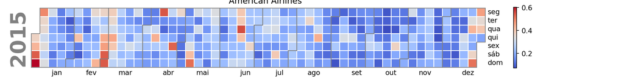

```python
# Importa bibliotecas necessárias
import pandas as pd
import matplotlib
matplotlib.use("Agg")
import matplotlib.pyplot as plt
import calplot

# Função para criar base de calendário
def base_calendario(stats, cia):
    df = stats[stats['AIRLINE'] == cia].copy() # Filtra o DataFrame 'stats' apenas para a companhia aérea especificada (cia)
    df['Data'] = pd.to_datetime(df['Data']) # Converte a coluna 'Data' para o tipo datetime
    df.set_index('Data', inplace=True) # Define a coluna 'Data' como índice do DataFrame (necessário para usar no calplot)

    return df['Perc'] # Retorna apenas a coluna 'Perc' (percentual de atrasos), indexada por data

# Cria as séries de percentuais de atraso para cada companhia aérea
cAA = base_calendario(in5, 'AA')
cDL = base_calendario(in5, 'DL')
cUA = base_calendario(in5, 'UA')
cUS = base_calendario(in5, 'US')

# Gera e exibe o gráfico de calendário (heatmap) para cada companhia aérea
calplot.calplot(cAA, cmap=plt.get_cmap('coolwarm'), suptitle="American Airlines")
plt.show()
```

```
findfont: Font family 'Helvetica' not found.
findfont: Font family 'Helvetica' not found.
findfont: Font family 'Helvetica' not found.
findfont: Font family 'Helvetica' not found.
findfont: Font family 'Helvetica' not found.
findfont: Font family 'Helvetica' not found.
```

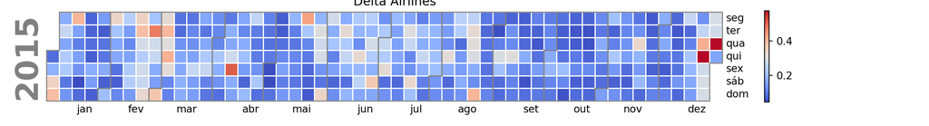

```python
calplot.calplot(cDL, cmap=plt.get_cmap('coolwarm'), suptitle="Delta Airlines")
plt.show()
```

```
findfont: Font family 'Helvetica' not found.
findfont: Font family 'Helvetica' not found.
findfont: Font family 'Helvetica' not found.
findfont: Font family 'Helvetica' not found.
findfont: Font family 'Helvetica' not found.
findfont: Font family 'Helvetica' not found.
```

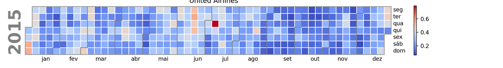

```python
calplot.calplot(cUA, cmap=plt.get_cmap('coolwarm'), suptitle="United Airlines")
plt.show()
```

```
findfont: Font family 'Helvetica' not found.
findfont: Font family 'Helvetica' not found.
findfont: Font family 'Helvetica' not found.
findfont: Font family 'Helvetica' not found.
findfont: Font family 'Helvetica' not found.
findfont: Font family 'Helvetica' not found.
```

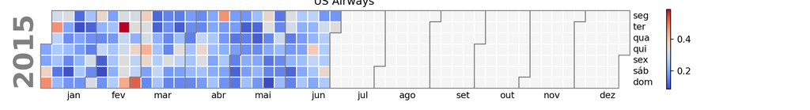

```python
calplot.calplot(cUS, cmap=plt.get_cmap('coolwarm'), suptitle="US Airways")
plt.show()
```